# Using the `simulate` package in `R`!

A starter vignette

Welcome to the `simulate` package! This `R` package helps `R` coders to conduct statistical simulations using their regression models.

## Why `simulate`?

*Statistical simulation* refers to generating model predictions for a hypothetical observation with specific traits (usual the average case in the dataset), using repeated simulations (random draws) to account for estimation and fundamental uncertainty.

The idea was popularized by Gary King and colleagues’ Stata package `Clarify` (King, Tomz, and Wittenberg 2000), and extended to `R` through the work of Kosuke Imai, Olivia Lau, Gary King, Christine Choirat, and many more via the `Zelig` package in `R`. Choirat et al. (2018).

With Zelig recently going offline, the `simulate` package provides a lightweight stand-in for regular `Zelig` users, supporting basic models from the `lm()`, `glm()`, `MASS::glm.nb()`, and `betareg:betareg()` functions.

## Install Package from Github

You can install `simulate` from Github using the `devtools` package’s `install_github()` function. (Sorry, no CRAN package right now!)

```r
# Load devtools
library(devtools)
# Install package from github!
install_github("timothyfraser/simulate",
               # and get the package's dependencies
               dependencies = TRUE, upgrade = TRUE)
```

To get started, please load the `simulate` and `tidyverse` packages! `simulate` is intended to be used in tandem with `tidyverse` functions from `ggplot2` and `dplyr`; they are necessary for running `simulate` functions.

```r
library(simulate) # for tidy simulation!
library(tidyverse) # for tidy data wrangling and visualization!
```

## Workflow

Using the `simulate` package involves a short string of key functions, including `equate()`, `calculate()`, `simulate()`, `tabulate()`, and `illustrate()`. See Figure 1!

[interactive chart not shown]

Figure 1: Sample Workflow in `simulate` package!

## Example

For example, let’s use the famous `mtcars` dataset to simulate the effects of horse power (`hp`) and cylinders (`cyl`) on the mileage (`mpg`) of 32 fancy cars.

A usual `simulate` package query might look a bit like **this below**.

```r
# Using a sample dataset
mtcars %>%
  # Make a model
  mutate(cyl = factor(cyl)) %>%
  lm(formula = mpg ~ hp + cyl) %>%
  # Simulate estimate uncertainty
  equate() %>%
  # Calculate predictions from simulated equations
  calculate(setx = list(hp = c(100, 150, 200))) %>%
  # Simulate fundamental uncertainty
  simulate() %>%
  # for each setx case
  group_by(case) %>%
  # summarize results!
  tabulate(qi = "ev", mu = 0)
```

In the following sections, I’ll break down each of these functions with examples!

## 1. Make Model Object

First, we’ll use the `lm()` function to create a simple ordinary least squares model, called `m`, with `mpg` as the outcome and `hp` and `cyl` as predictors. We’ll turn `cyl` into a `factor()`, to demonstrate how to use factors / fixed effects here.

*Note:* Current limitations of the package require that you turn predictors into `factor()` format *before* regressing them in the model. `simulate` will not work otherwise.

```r
m <- mtcars %>%
  mutate(cyl = factor(cyl)) %>%
  lm(formula = mpg ~ hp + cyl)
```

## 2. `equate()` estimation uncertainty

Next, we’ll use `equate()` to generate 1000 model equations, each very close to the observed model equation in model `m`, but each just slightly different. These slightly differing model equations represent `estimation uncertainty`, the uncertainty in the true values of our beta coefficients.

Exactly like in `Zelig` and `CLARIFY`, `equate()` takes random draws from a multivariate normal distribution using the model’s coefficients and variance-covariance matrix.

```r
myequations <- m %>% equate()
```

A bonus of the `simulate` package is that `equate()` gives you more control, allowing you to work directly with our simulated equations, in the event that you only want to account for estimation uncertainty, or in the event that you want to reuse the exact same multivariate normal distribution.

You can set a seed with `seed = 12345`, for example, to reproduce results. To change the number of simulated equations sampled, adjust `reps` from `reps = 1000` (default) to, for example, `reps = 3`. (Though 1000 is standard!)

```r
# for example,
m %>% equate(reps = 3, seed = 12345)
```

```
#> # A tibble: 3 × 5
#>   replicate `(Intercept)`       hp  cyl6  cyl8
#> *     <int>         <dbl>    <dbl> <dbl> <dbl>
#> 1         1          28.2 -0.0310  -5.26 -6.91
#> 2         2          30.1 -0.0384  -5.65 -7.01
#> 3         3          26.4 -0.00544 -4.01 -9.03
```

## 3. `calculate()` simulated values

Next, we’re going to use `calculate()` to compute our simulated equations. By default, `calculate()` takes the median of numeric variables and the mode of categorical variables, but you can simulate at specific values, using the argument `setx = list(...)` (much like in `Zelig`).

For example, let’s calculate the simulated `mpg` for an otherwise average car as its `hp` increases from `100` to `150` to `200`.

```r
mycalc <- myequations %>%
  calculate(setx = list(hp = c(100, 150, 200)))
```

```
#> [1] "Predictor values set using contents of setx; otherwise, set to medians and modes by default."
```

`calculate` outputs a data.frame containing `replicate`, the id for each simulated equation, `ysim`, the predictions from each simulated equation, `sigma`, the residual standard error for the model, and `case`, the unique ID for the *n* conditions supplied in `setx.` We used `hp = c(100, 150, 200)`, totalling 3 conditions, so `case` runs from `1` to `3`.

```r
mycalc %>% head(3)
```

[output not shown]

## 4. `simulate()` fundamental uncertainty

Fourth, we can use `simulate()` to simulate fundamental uncertainty. This takes each simulated value outputted by `calculate()` and then constructs a distribution fitting the outcome variable (normal for `lm()`, poisson for `glm(family = "Poisson")`, etc.)

`simulate()` outputs a `tibble` containing `replicate`, the unique ID for each simulated equation, `pv`, the predicted value for that equation, `ev`, the expected value for that equation, and `case`, the unique ID for each condition specified in `setx` in the `calculate()` function.

```r
mysim <- mycalc %>% simulate()
```

Check it out!

```r
mysim %>% head()
```

```
#> # A tibble: 6 × 4
#>   replicate  case    pv    ev
#>   <chr>     <int> <dbl> <dbl>
#> 1 1             1 21.8   20.0
#> 2 1             2 20.1   17.9
#> 3 1             3 15.5   15.7
#> 4 10            1 13.8   15.3
#> 5 10            2 16.4   14.4
#> 6 10            3  7.90  13.6
```

But what *are* `ev` and `pv`?

- To make predicted values (`pv`), it simulates 1 random draw from this distribution.
- To make expected values (`ev`), it simulates 1000 random draws from this distribution, and takes the average of them.

Predicted values are encouraged when making predictions about the future, since they generate wider confidence intervals, while expected values are generally encouraged for explaining the past, as they generate more precise estimates, averaging over fundamental uncertainty.

We can do a lot with these values using `ggplot2`! The most direct visualization is usually a `geom_point()` or `geom_jitter()`, but `geom_violin()` can be handy at showing distributions too!

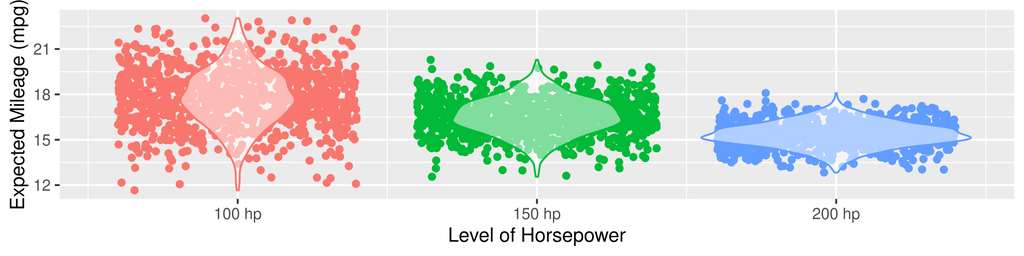

```r
mysim %>%
  # map aesthetics
  ggplot(mapping = aes(x = case, y = ev, color = factor(case), group = factor(case) )) +
  # Show full 1000 expected value range
  geom_jitter() +
  # Show distributions
  geom_violin(fill = "white", alpha = 0.5) +
  # Relabel the x-axis's case variable as needed
  scale_x_continuous(
    breaks = c(1, 2, 3),
    labels = c("100 hp", "150 hp", "200 hp")) +
  # Skip legend
  guides(color = "none") +
  # Add labels
  labs(x = "Level of Horsepower", y = "Expected Mileage (mpg)",
       color = "Conditions")
```

## 5. `illustrate()` results

What if we want to visualize not just the overall range, but varying confidence intervals? To get that data, we can use `illustrate()` on a quantity of interest (`qi`). Be sure to use `group_by(case)` to get confidence intervals for each different condition from `setx`!

```r
mybands <- mysim %>%
  group_by(case) %>%
  illustrate(qi = "ev")
```

Check it out! Each row has a unique ID describing a band, and together, this tidy dataframe can be used to visualize the full range of confidence intervals in `ggplot2.`

```r
mybands %>% head()
```

```
#> # A tibble: 6 × 5
#> # Groups:   case [1]
#>    case group ci    lower upper
#>   <int> <int> <fct> <dbl> <dbl>
#> 1     1     1 99.9%  11.9  12.5
#> 2     1     2 99%    12.5  14.0
#> 3     1     3 95%    14.0  14.6
#> 4     1     4 90%    14.6  17.8
#> 5     1     5 90%    17.8  21.0
#> 6     1     6 95%    21.0  21.5
```

We can visualize `mybands` like so in `ggplot2` (but for ideas, check out my other tutorials on [RPubs](https://rpubs.com/timothyfraser)!)

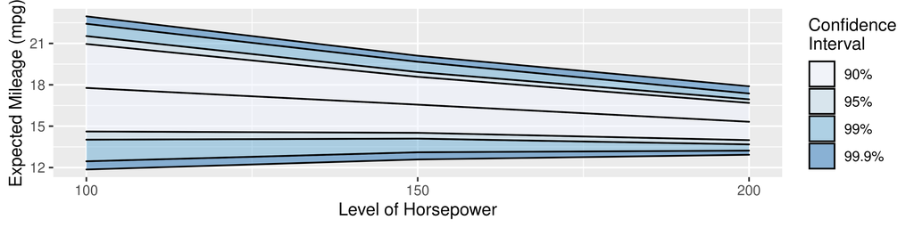

```r
mybands %>%
  # Map aethestics
  ggplot(mapping = aes(x = case, ymin = lower, ymax = upper, group = group, fill = ci)) +
  # Make a pretty ribbon for each group!
  geom_ribbon(alpha = 0.5, color = "black") +
  # Shade the ribbon!
  scale_fill_brewer(palette = "Blues") +
  # Relabel the x-axis's case variable as needed
  scale_x_continuous(
    breaks = c(1, 2, 3),
    labels = c(100, 150, 200)) +
  # Add lables
  labs(x = "Level of Horsepower", y = "Expected Mileage (mpg)",
       fill = "Confidence\nInterval")
```

`illustrate()` can even be used on other outputs, like our model equations from `equate()`.

```r
myequations %>%
  illustrate(qi = "hp") %>%
  head(3)
```

```
#> # A tibble: 3 × 4
#>   group ci      lower   upper
#>   <int> <fct>   <dbl>   <dbl>
#> 1     1 99.9% -0.0709 -0.0625
#> 2     2 99%   -0.0625 -0.0548
#> 3     3 95%   -0.0548 -0.0507
```

## 6. `tabulate()` results

Finally, do you just want a nice model table? Can do! We can tabulate these results like so, supplying the `tabulate()` function a column to tabulate.

### 6.1 Tabulating Confidence Intervals

`tabulate()` will return an `estimate`, the median simulated value for your quantity of interest (`qi`), `lower` and `upper` simulated confidence intervals (defaulting at 95% as shown by `ci = 0.95`), and `se`, showing the standard deviation of simulations. We can even pair it with `group_by(case)` to get estimates for each level.

```r
mysim %>%
  group_by(case) %>%
  tabulate(qi = "ev", ci = 0.95, mu = 0)
```

```
#> # A tibble: 3 × 8
#>    case term  estimate lower upper    se p_value stars
#>   <int> <chr>    <dbl> <dbl> <dbl> <dbl>   <dbl> <chr>
#> 1     1 ev        17.8  14.0  21.5 1.90        0 ***
#> 2     2 ev        16.6  14.1  18.9 1.23        0 ***
#> 3     3 ev        15.3  13.7  16.9 0.809       0 ***
```

### 6.2 Hypothesis Testing with `mu`

Further, you can easily test *whatever hypothesis you want* using the `mu` parameter above. `mu` sets the null hypothesis for the estimate. The `p_value` shows a one-tailed test of what percentage of simulations cross `mu` from the estimate. As in, if the estimate is positive and `mu = 0`, what share of simulations are negative? Our p-value for the null hypothesis `mu = 0` above is `0%`, but that’s not very surprising.

Instead, `tabulate()`’s `mu` parameter becomes handy when testing hypotheses about our simulations against real world benchmarks. For instance, did PTSD rates after a disaster exceed the average level in the population? As X increases from 1 to 10, how often do we expect those rates to exceed `mu` percent of residents?

Or in this case, the median mileage (`mpg`) in our dataset is `19.2` miles per gallon. So a meaningful quantity of interest might be, at what level of horsepower does a car’s mileage really begin to exceed average levels?

```r
mtcars$mpg %>% median()
```

```
#> [1] 19.2
```

We can test this hypothesis by setting `mu` to `19.2`. We see below that otherwise-average cars with a `hp` of `100` (`case == 1`) do not tend to have `mpg` that are significantly different from the median. However, as their `hp` increases (`case == 2` and `case == 3`), their `mpg` actually becomes significantly *lower* that median levels!

```r
mysim %>%
  group_by(case) %>%
  tabulate(qi = "ev", ci = 0.95, mu = 19.2)
```

```
#> # A tibble: 3 × 8
#>    case term  estimate lower upper    se p_value stars
#>   <int> <chr>    <dbl> <dbl> <dbl> <dbl>   <dbl> <chr>
#> 1     1 ev        17.8  14.0  21.5 1.90    0.236 " "
#> 2     2 ev        16.6  14.1  18.9 1.23    0.014 "*"
#> 3     3 ev        15.3  13.7  16.9 0.809   0     "***"
```

### 6.3 First Differences with `tabulate()`

`mu` is especially useful when computing first differences (also known as marginal effects), meaning the change in expected or predicted values. Let’s give it a try!

```r
myfd <- mysim %>%
  # Pivot the case ids into columns
  pivot_wider(id_cols = c(replicate), names_from = case,
              values_from = ev, names_prefix = "ev_") %>%
  # And calculate how much GREATER ev is for case 3 than for case 1!
  mutate(fd = ev_3 - ev_1)
```

Check it out!

```r
myfd %>% head(3)
```

```
#> # A tibble: 3 × 5
#>   replicate  ev_1  ev_2  ev_3    fd
#>   <chr>     <dbl> <dbl> <dbl> <dbl>
#> 1 1          20.0  17.9  15.7 -4.36
#> 2 10         15.3  14.4  13.6 -1.70
#> 3 100        17.4  16.9  16.4 -1.05
```

Or if you feel more comfortable mixing base R and tidyverse coding, try using brackets in `summarize()`, which does the same thing:

```r
mysim %>%
  group_by(replicate) %>%
  summarize(
    ev_1 = ev[case == 1],
    ev_3 = ev[case == 3],
    fd = ev_3 - ev_1) %>%
  head(3)
```

```
#> # A tibble: 3 × 4
#>   replicate  ev_1  ev_3    fd
#>   <chr>     <dbl> <dbl> <dbl>
#> 1 1          20.0  15.7 -4.36
#> 2 10         15.3  13.6 -1.70
#> 3 100        17.4  16.4 -1.05
```

### 6.4 Coefficient Tables

We might also just want to make a simple coefficent table using `tabulate()`! Many models today violate the assumption of independence of observations, which is required to compute standard errors from a variance-covariance matrix. However, we could just simulate these error instead, by taking the standard deviation from our estimation uncertainty estimates from `equate()`.

When applying `tabulate()` to an output from `equate()`, you do not need to specify a quantity of interest (`qi`); `tabulate()` will build the coefficient table for all variables in the model.

Here, `mu = 0` by default, which is the usual null hypothesis for beta coefficients. (However, you can change `mu` to anything, allowing you to do mini-linear hypothesis tests if you want!)

```r
myequations %>%
  tabulate(ci = 0.95, mu = 0)
```

```
#> # A tibble: 4 × 7
#>   term        estimate lower_ci upper_ci     se p_value stars
#>   <chr>          <dbl>    <dbl>    <dbl>  <dbl>   <dbl> <chr>
#> 1 (Intercept)  28.7     25.4    31.8     1.62     0     ***
#> 2 hp           -0.0240  -0.0548  0.00687 0.0157   0.064 .
#> 3 cyl6         -5.97    -9.06   -2.80    1.61     0.001 ***
#> 4 cyl8         -8.52   -13.2    -3.67    2.32     0     ***
```

(Note: All p-values from these simulations are currently one-tailed, reflecting what share of simulations are on the opposite side of `mu` from the estimate. However, this also means that we know that the *other* tail *does* exceed *mu*, so two-tailed testing isn’t strictly necessary for this method. Please report results accordingly!)

# 7. Next Steps

Hope you enjoy! If you like it, share it! If you use the package, please do cite it! Have questions? Feel free to reach out on [Github](https://github.com/timothyfraser/simulate). Happy simulating!

```r
# Get the citation like this!
citation("simulate")
```

```
#>
#>
#>   Fraser T (2022). _simulate: Tidy Simulation for Statistical Models_.
#>   R package version 0.0.0.9000.
#>
#> A BibTeX entry for LaTeX users is
#>
#>   @Manual{,
#>     title = {simulate: Tidy Simulation for Statistical Models},
#>     author = {Timothy Fraser},
#>     year = {2022},
#>     note = {R package version 0.0.0.9000},
#>   }
```

## References

Choirat, Christine, James Honaker, Kosuke Imai, Gary King, and Olivia Lau. 2018. *Zelig: Everyone’s Statistical Software*. http://zeligproject.org/.

Imai, Kosuke, Gary King, and Olivia Lau. 2008. “Toward a Common Framework for Statistical Analysis and Development.” *Journal of Computational Graphics and Statistics* 17 (4): 892–913. http://j.mp/msE15c.

King, Gary, Michael Tomz, and Jason Wittenberg. 2000. “Making the Most of Statistical Analyses: Improving Interpretation and Presentation.” *American Journal of Political Science*, 347–61.